# 10. praktikum

## Hii-ruut-testi jäägid

Hii-ruut-test ise ütleb lihtsalt, et kahe kategoriaalse tunnuse vahel on statistiliselt oluline seos, aga ei ütle midagi selle kohta, milline see seos on. Seepärast oleks kasulik vaadata Pearsoni jääkide abil, millised erinevused tegelike ja oodatud sageduste vahel on suuremad. Nn Pearsoni jääke arvutatakse valemiga $\frac{(o-e)}{\sqrt{e}}$.

```r
# Näiteks lühikese sisseütlevaga pärisnimede jääk on
(t$observed["Lühike", "Pärisnimi"]-t$expected["Lühike", "Pärisnimi"])/sqrt(t$expected["Lühike", "Pärisnimi"])
```

```
## [1] -2.194691
```

```r
# Jäägid saab kätte ka testi väljundist
t$residuals
```

```
##        Pärisnimi    Üldnimi
## Lühike -2.194691  0.8959787
## Pikk    2.194691 -0.8959787
```

```r
# Jääkide ruutude summa ongi hii-ruut-statistik
sum(t$residuals^2)
```

```
## [1] 11.23889
```

Kui jääk on positiivne, on tegelik sagedus suurem kui oodatud ja konkreetne tunnuste kombinatsioon esineb sagedamini kui marginaalsageduste põhjal võiks oletada. Kui jääk on negatiivne, on tegelik sagedus väiksem kui oodatud. Näiteks pärisnimed esinevad oodatust harvemini lühikeses sisseütlevas käändes (nt *läksin Tartu*).

Mida suurem on Pearsoni jäägi absoluutväärtus, seda enam on tõenäoliselt konkreetne lahter statistiliselt olulise hii-ruut-statistiku väärtusesse panustanud.

Selleks aga, et näha, millised jäägid esindavad **olulist** erinevust oodatud sagedustest, vaatame **standardiseeritud Pearsoni jääke**. Standardiseeritud jäägid R-i hii-ruut-testi kontekstis (ka tavalised Pearsoni jäägid on põhimõtteliselt standardiseeritud) väljendavad erinevust tegeliku ja oodatud sageduse vahel, mis on jagatud mitte ruutjuurega oodatud sagedustest (nagu tavaliste Pearsoni jääkide puhul), vaid ruutjuurega avaldisest, kus korrutatakse oodatud sagedused, 1 - oodatud sageduste osakaal ridade summast ja 1 - oodatud sageduste osakaal tulpade summast. Need on tuntud ka kui *adjusted residuals*.

Näiteks lühikeses sisseütlevas käändes pärisnime standardiseeritud jääk oleks

```r
(teg <- tab["Lühike", "Pärisnimi"]) # tegelik sagedus
```

```
## [1] 43
```

```r
(ood <- sum(tab["Lühike",]) * sum(tab[,"Pärisnimi"]) / sum(tab)) # oodatud sagedus
```

```
## [1] 60
```

```r
(std <- ood * (1 - ood/sum(tab["Lühike",])) * (1 - ood/sum(tab[,"Pärisnimi"]))) # korrutis
```

```
## [1] 25.71429
```

```r
(teg-ood)/sqrt(std)
```

```
## [1] -3.352445
```

```r
t$stdres
```

```
##        Pärisnimi   Üldnimi
## Lühike -3.352445  3.352445
## Pikk    3.352445 -3.352445
```

Kui olulisuse nivoo on 0.05, siis on statistiliselt olulised need jäägid, mis on suuremad kui 1.96 või väiksemad kui -1.96 (tihti ümardatakse ka 2 ja -2). Vastava kriitilise väärtuse võib leida nt funktsiooniga `qnorm(1-olulisuse_nivoo/2)`. Need jäägid näitavad, millised on need risttabeli lahtrid, mis panustavad hii-ruut-testi statistiliselt olulisse tulemusse enim ning milles erinevus oodatud ja tegelike sageduste vahel on kõige märgatavam.

## Seose tugevuse hindamine

Kategoriaalsete tunnuste vahelise seose tugevust saab mõõta näiteks Craméri V või φ-kordaja abil.

```r
# install.packages("effectsize")
library(effectsize)

cramers_v(tab)
```

```
## Cramer's V (adj.) |       95% CI
## --------------------------------
## 0.11              | [0.05, 1.00]
##
## - One-sided CIs: upper bound fixed at [1.00].
```

```r
phi(tab)
```

```
## Phi (adj.) |       95% CI
## -------------------------
## 0.11       | [0.05, 1.00]
##
## - One-sided CIs: upper bound fixed at [1.00].
```

```r
# install.packages("vcd")
library(vcd)

assocstats(tab)
```

```
##                     X^2 df   P(> X^2)
## Likelihood Ratio 11.373  1 0.00074531
## Pearson          11.239  1 0.00080101
##
## Phi-Coefficient   : 0.116
## Contingency Coeff.: 0.115
## Cramer's V        : 0.116
```

Sümmeetrilise 2x2 risttabeli puhul on Craméri V (ruutjuur hii-ruut-statistiku ja vaatluste arv * vabadusastmete arv jagatisest) ja φ-kordaja (ruutjuur hii-ruut-statistiku ja vaatluste arvu jagatisest) samad ja varieeruvad vahemikus nullist üheni.

- Nõrk seos: 0.1-0.3
- Keskmine seos: 0.3-0.5
- Tugev seos: > 0.5

Seose tugevust seostatakse vahel ka vabadusastmete arvuga (mida rohkem on vabadusastmeid, seda madalam on tugeva seose nivoo).

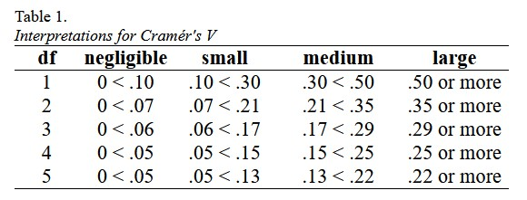

https://peterstatistics.com/CrashCourse/3-TwoVarUnpair/NomNom/NomNom3c.html

**NB!** Seose tugevuse hindamine ei käi samadel alustel nagu korrelatsioonikordajate puhul. Samuti ei näita Craméri V ega φ-kordaja seose suunda.

Suuremate (mitteruut)tabelite puhul võivad hakata kordajate väärtused erinema. Craméri V jääb alati vahemikku 0-1, φ-kordaja väärtus võib minna ka üle 1.

Tavaliselt kasutatakse 2x2 tabelist suuremate tabelite puhul Craméri V-d, sest see on võrreldav ka eri suurustega tabelite korral.

## Kuidas hii-ruut-testi tulemust raporteerida

Hii-ruut-testi tegemisel on tavaks esitada hii-ruut-statistiku väärtus koos vabadusastmete arvu ja vaatluste arvuga ning *p*-väärtus. Võib lisada ka info mõju suuruse kohta.

```
##
##  Pearson's Chi-squared test
##
## data:  tab
## X-squared = 11.239, df = 1, p-value = 0.000801
```

Hii-ruut-testi tulemus on statistiliselt oluline: *X<sup>2</sup>*(1, N = 840) = 11.239, *p* < 0.001. Craméri V on 0.12, mille põhjal on tegemist siiski nõrga seosega.

```r
report::report_text(chisq.test(tab, correct = F))
```

```
## In the report() function, for htest objects, you can try providing the
##   data argument manually, e.g., report(x, data = data).
```

```
## Effect sizes were labelled following Funder's (2019) recommendations.
##
## The Pearson's Chi-squared test of independence between suggests that the effect
## is statistically significant, and small (chi2 = 11.24, p < .001; Adjusted
## Cramer's v = 0.11, 95% CI [0.05, 1.00])
```

## Testi võimsus

Ka hii-ruut-testi jaoks võib arvutada välja testi võimsuse, mis ütleb, kui suure tõenäosusega leiame sellise valimi suuruse, vabadusastmete arvu, mõju suuruse ja olulisuse nivoo korral olulise seose juhul, kui see tõesti olemas on. Testi võimsust tasub kontrollida eriti siis, kui saad testiga statistiliselt ebaolulise tulemuse.

```r
library(pwr)
w <- assocstats(tab)$cramer # mõju suurus (siin Craméri V)
N <- sum(tab) # vaatluste arv
df <- t$parameter # hii-ruut-testi vabadusastmete arv (t <- chisq.test(tab))

pwr.chisq.test(w = w, N = N, df = df, sig.level = 0.05)
```

```
##
##      Chi squared power calculation
##
##               w = 0.1156703
##               N = 840
##              df = 1
##       sig.level = 0.05
##           power = 0.9181117
##
## NOTE: N is the number of observations
```

Siin näiteks on tõenäosus, et me **ei tee teist tüüpi viga** (ütleme, et seost ei ole, kui tegelikult on), ~92%. See on päris hea.

Võimsuse analüüsiga saab ka otsustada, kui palju andmeid on vaja selleks, et leida teatud olulisuse nivool ning kindla võimsusega mingi soovitud suurusega mõju.

```r
# library(pwr)
w <- 0.5 # tugev mõju
df <- 1
power <- 0.9

pwr.chisq.test(w = w, df = df, power = power, sig.level = 0.05)
```

```
##
##      Chi squared power calculation
##
##               w = 0.5
##               N = 42.02968
##              df = 1
##       sig.level = 0.05
##           power = 0.9
##
## NOTE: N is the number of observations
```

```r
# võrdle
w <- 0.1 # nõrk mõju

pwr.chisq.test(w = w, df = df, power = power, sig.level = 0.05)
```

```
##
##      Chi squared power calculation
##
##               w = 0.1
##               N = 1050.742
##              df = 1
##       sig.level = 0.05
##           power = 0.9
##
## NOTE: N is the number of observations
```

Kuna tugevamat mõju (*w*) on lihtsam andmetest tuvastada, on selleks vaja ka vähem vaatlusi. Väikese (aga olulise) mõju tuvastamiseks on aga jällegi vaja rohkem vaatlusi.

## Harjutus 2

Leia, millised soo ja valimisnimekirja kombinatsioonid panustavad kõige enam hii-ruut-testi tulemusse (standardiseeritud **jäägid**), kui tugev on **seos** soo ja valimisnimekirja vahel ning milline on testi **võimsus**.

Kontrolli seejärel, kas äkki tuli küsimustiku andmete põhjal seos lemmikjoogi ja kvantitatiivsete meetodite kogemuse vahel ebaoluline seetõttu, et testi võimsus polnud selle andmehulga jaoks piisav.

## Fisheri täpne test ja G-test

Mida teha siis, kui andmestikus on **teoreetilised** sagedused, mis on < 5 või lausa 0? Tihti räägitakse, et sellistel juhtudel hii-ruut-test ei sobi.

Alternatiivid on näiteks **Fisheri täpne test** või **G-test**.

Vaatleme nüüd käändevormi sõltuvust sellest, millise sõnaliigiga on tegemist.

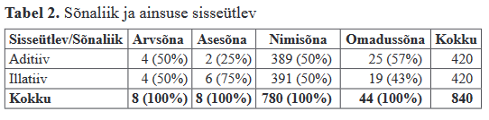

Siiman 2015: 215

```r
tab2 <- matrix(c(4, 4, 2, 6, 389, 391, 25, 19),
               nrow = 2, ncol = 4,
               dimnames = list(c("Lühike", "Pikk"),
                               c("Arvsõna", "Asesõna", "Nimisõna", "Omadussõna")))

tab2
```

```
##        Arvsõna Asesõna Nimisõna Omadussõna
## Lühike       4       2      389         25
## Pikk         4       6      391         19
```

```r
(t2 <- chisq.test(tab2))
```

```
##
##  Pearson's Chi-squared test
##
## data:  tab2
## X-squared = 2.8233, df = 3, p-value = 0.4197
```

```r
t2$expected
```

```
##        Arvsõna Asesõna Nimisõna Omadussõna
## Lühike       4       4      390         22
## Pikk         4       4      390         22
```

Neli oodatud sagedust on < 5.

```r
fisher.test(tab2)
```

```
##
##  Fisher's Exact Test for Count Data
##
## data:  tab2
## p-value = 0.4329
## alternative hypothesis: two.sided
```

Fisheri test arvutab **täpset** tõenäosust kohata valimis esinevat tegelike sageduste jaotust. Tõenäosuse arvutamiseks loob ta ridade ja tulpade marginaalsageduste põhjal kõik võimalikud viisid, kuidas sagedused võiksid olla lahtrites jaotunud. See aga teeb Fisheri testi arvutuslikult väga kompleksseks ja ressursiahneks, mistõttu ei tööta test väga suurte andmestikega.  
Argumendiga `workspace` võib anda algoritmile juurde lisamälu, ent see võib teha aeglaseks kõik muud protsessid teie arvutis.

```r
valimised <- read.delim("data/kandidaadid_2023.csv")
fisher.test(valimised$nimekiri, valimised$sugu, workspace = 100000000000)
```

G-test on hii-ruut-testile väga sarnane, ent selle valem statistiku arvutamiseks on pisut erinev: $G = 2\sum_i O_i log(\frac{O_i}{E_i})$.

```r
# install.packages("DescTools")
DescTools::GTest(tab2)
```

```
##
##  Log likelihood ratio (G-test) test of independence without correction
##
## data:  tab2
## G = 2.9189, X-squared df = 3, p-value = 0.4043
```

[Vaata ka teisi kategoriaalsete andmete teste.](https://en.wikipedia.org/wiki/List_of_analyses_of_categorical_data)

## Monte-Carlo simulatsioon

Veel üks variant seoste hindamiseks tabelites, kus on ka väikeseid sagedusi, mille puhul tavaline hii-ruut-test muutub pirtsakaks, on kasutada *p*-väärtuse leidmiseks nn Monte-Carlo simulatsiooni. Selle käigus seotakse testi *p*-väärtus lahti eeldusest, et hii-ruut-statistik on pärit pidevast hii-ruut-jaotusest, kus kahe tunnuse vaheline seos muutub statistiliselt oluliseks kindla vabadusastmete arvu ja sellele vastava statistiku väärtuse korral.

```r
chisq.test(tab2, simulate.p.value = TRUE)
```

```
##
##  Pearson's Chi-squared test with simulated p-value (based on 2000
##  replicates)
##
## data:  tab2
## X-squared = 2.8233, df = NA, p-value = 0.4418
```

Monte-Carlo simulatsioonis tehakse risttabeli oodatud sageduste põhjal mitu (nt 2000) juhuslikku “tegelike sagedustega” tabelit, varieerides iga kord pisut tõenäosust, millega mingi tunnuste kombinatsioon esineda võiks. “Tegelike sagedustega” juhuslikud tabelid on aga ikkagi küllalt lähedal oodatud sagedustega tabelile (ehk tabelile, mille põhjal kahe tunnuse vahel ei tohiks olla mingit seost).

Näiteks kui oodatud sagedustega tabel näeb välja selline:

```r
chisq.test(tab2)$expected
```

```
##        Arvsõna Asesõna Nimisõna Omadussõna
## Lühike       4       4      390         22
## Pikk         4       4      390         22
```

siis kolm juhuslikult genereeritud tabelit võiksiv välja näha umbes sellised:

```r
(ts1 <- matrix(c(3,6,1,4,368,410,19,29), nrow= 2,
               dimnames = list(c("Lühike", "Pikk"),
                               c("Arvsõna", "Asesõna", "Nimisõna", "Omadussõna"))))
```

```
##        Arvsõna Asesõna Nimisõna Omadussõna
## Lühike       3       1      368         19
## Pikk         6       4      410         29
```

```r
(ts2 <- matrix(c(8,5,3,7,383,381,25,28), nrow= 2,
               dimnames = list(c("Lühike", "Pikk"),
                               c("Arvsõna", "Asesõna", "Nimisõna", "Omadussõna"))))
```

```
##        Arvsõna Asesõna Nimisõna Omadussõna
## Lühike       8       3      383         25
## Pikk         5       7      381         28
```

```r
(ts3 <- matrix(c(3,2,3,1,394,395,21,21), nrow= 2,
               dimnames = list(c("Lühike", "Pikk"),
                               c("Arvsõna", "Asesõna", "Nimisõna", "Omadussõna"))))
```

```
##        Arvsõna Asesõna Nimisõna Omadussõna
## Lühike       3       3      394         21
## Pikk         2       1      395         21
```

```r
# jne
```

Juhuslikult genereeritud tabelite põhjal leitakse hii-ruut-statistikud (kui on 2000 kordust, siis 2000 statistiku väärtust), kasutades esialgse tabeli oodatud sagedusi.

```r
hiid <- c(
  sum(((ts1-t2$expected)^2)/t2$expected),
  sum(((ts2-t2$expected)^2)/t2$expected),
  sum(((ts3-t2$expected)^2)/t2$expected)
)
hiid
```

```
## [1] 8.403030 9.128788 3.946037
```

Lõpuks arvutatakse nende kordade osakaal simuleeritud tabelitest, mille puhul leitud hii-ruut-statistik oli sama suur või suurem kui algse (ilma pidevusparanduseta) testi statistik 2.82331. See osakaal ongi testi *p*-väärtus.

```r
chisq.test(tab2, correct = FALSE)
```

```
##
##  Pearson's Chi-squared test
##
## data:  tab2
## X-squared = 2.8233, df = 3, p-value = 0.4197
```

```r
set.seed(1)
chisq.test(tab2, simulate.p.value = TRUE, B = 3000)
```

```
##
##  Pearson's Chi-squared test with simulated p-value (based on 3000
##  replicates)
##
## data:  tab2
## X-squared = 2.8233, df = NA, p-value = 0.4459
```

## Järgmisel korral

Järgmisel korral läheme kahe tunnuse vaheliste seoste hindamise juurest regressioonimudelite juurde, mis võimaldavad ühe tunnuse muutumist kirjeldada enamate tunnuste kaudu. **NB!** Järgmine praktikum alles ülejärgmisel nädalal (30.03)!

## Funktsioonide sõnastik

- `chisq.test()` - tee hii-ruut-test, sisendiks sagedustega risttabel või andmetabeli kahe tulba nimed
- `DescTools::Gtest()` - tee G-test, sisendiks sagedustega risttabel või andmetabeli kahe tulba nimed
- `fisher.test()` - tee Fisheri täpne test, sisendiks sagedustega risttabel või andmetabeli kahe tulba nimed
- `pwr::pwr.chisq.test()` - leia hii-ruut-testi võimsus
- `tidyverse::rownames_to_column()` - muuda tabeli või `data.frame`-objekti reanimed eraldi tunnuseks/tulbaks andmestikus
- `vcd::assocstats()` - leia kategoriaalsete tunnuste vahelise seose tugevuse mõõdikud